# BCG_Forage_Simulation_Financial_Analysis_1

FORAGE BCG SIMULATION : FINACIAL ANALYSIS of AAPL, MSFT, and TSLA 10-K FILINGS

1. Data Collection: The financial data for Apple, Microsoft, and Tesla was sourced directly from their respective Form 10-K filings, which are publicly available through the U.S. Securities and Exchange Commission's (SEC) EDGAR database and the companies' Investor Relations websites. The specific data points extracted for the fiscal years 2022, 2023, and 2024 were: Total Revenue, Net Income, Total Assets, Total Liabilities, Cash Flow from Operating Activities.
2. Data Preparation and Cleaning: A spreadsheet containing the extracted data was exported as a CSV file. The file was loaded into a Pandas DataFrame in Google Colab. The following data cleaning and transformation steps were performed: Reading the data: The skiprows=1 and header=0 parameters were used in pd.read_csv() to correctly load the data, ignoring a metadata row.

```python
# Import all necessary libraries
import pandas as pd

# Mount the drive and fetch the CSV
from google.colab import drive
drive.mount('/content/drive')

file_path = '/content/drive/MyDrive/Forage - BCG simulation/10-K_financial report_forage.csv'
df = pd.read_csv(file_path, skiprows=1, header=0)

print("Column headers in the DataFrame:")
print(df.columns)

print("\nFirst 5 rows of the DataFrame:")
print(df.head())
```

```
Column headers in the DataFrame:
Index(['Number', 'Company Name', 'Fiscal Year', 'Total revenue(Millions USD)',
       'Net Income(Millions USD)', 'Total Assets(Millions USD)',
       'Total Liabilities(Millions USD)',
       'Cash Flow from Operating Activities(Millions USD)'],
      dtype='object')

First 5 rows of the DataFrame:
   Number Company Name  Fiscal Year Total revenue(Millions USD)  \
0       1  NASDAQ:AAPL         2022                     394,328
1       2  NASDAQ:AAPL         2023                     383,285
2       3  NASDAQ:AAPL         2024                     391,035
3       4  NASDAQ:MSFT         2022                     198,270
4       5  NASDAQ:MSFT         2023                     211,915

  Net Income(Millions USD) Total Assets(Millions USD)  \
0                   99,803                    352,755
1                   96,995                    352,583
2                   93,736                    364,980
3                   72,738                    364,840
4                   72,361                    411,976

  Total Liabilities(Millions USD)  \
0                         302,083
1                         290,437
2                         308,030
3                         198,298
4                         205,753

  Cash Flow from Operating Activities(Millions USD)
0                                           122,151
1                                           110,543
2                                           118,254
3                                            89,035
4                                            87,582
```

```python
# Check the data types to see the issue
print("Original data types:")
print(df.dtypes)
```

```
Original data types:
Number                                                int64
Company Name                                         object
Fiscal Year                                           int64
Total revenue(Millions USD)                          object
Net Income(Millions USD)                             object
Total Assets(Millions USD)                           object
Total Liabilities(Millions USD)                      object
Cash Flow from Operating Activities(Millions USD)    object
dtype: object
```

- Calculating year-over-year changes for each financial metric after changing the original data types of the columns to appropriate ones for the accurate time - series output.

```python
# List of columns that need to be converted to numeric
financial_columns = [
    'Total revenue(Millions USD)',
    'Net Income(Millions USD)',
    'Total Assets(Millions USD)',
    'Total Liabilities(Millions USD)',
    'Cash Flow from Operating Activities(Millions USD)'
]

for col in financial_columns:
    # 1. Convert to string and remove commas (common issue with large numbers)
    # 2. Convert to numeric. 'errors="coerce"' will turn unconvertible values into NaN.
    df[col] = pd.to_numeric(df[col].astype(str).str.replace(',', ''), errors='coerce')

# Verify data types after conversion (optional, but good for checking)
print("\nData types after conversion:")
print(df.dtypes)

# Sort the DataFrame by 'Company Name' and 'Fiscal Year'
df = df.sort_values(by=['Company Name', 'Fiscal Year'])

# Calculate Revenue Growth (%)
df['Revenue Growth (%)'] = df.groupby('Company Name')['Total revenue(Millions USD)'].pct_change() * 100

# Calculate Net Income Growth (%)
df['Net Income Growth (%)'] = df.groupby('Company Name')['Net Income(Millions USD)'].pct_change() * 100

# Display the DataFrame with the new growth columns
print("\nDataFrame with Growth Percentages:")
print(df)
```

```
Data types after conversion:
Number                                                 int64
Company Name                                          object
Fiscal Year                                            int64
Total revenue(Millions USD)                            int64
Net Income(Millions USD)                               int64
Total Assets(Millions USD)                             int64
Total Liabilities(Millions USD)                        int64
Cash Flow from Operating Activities(Millions USD)      int64
Revenue Growth (%)                                   float64
Net Income Growth (%)                                float64
dtype: object

DataFrame with Growth Percentages:
   Number Company Name  Fiscal Year  Total revenue(Millions USD)  \
0       1  NASDAQ:AAPL         2022                       394328
1       2  NASDAQ:AAPL         2023                       383285
2       3  NASDAQ:AAPL         2024                       391035
3       4  NASDAQ:MSFT         2022                       198270
4       5  NASDAQ:MSFT         2023                       211915
5       6  NASDAQ:MSFT         2024                       245122
6       7  NASDAQ:TSLA         2022                        81462
7       8  NASDAQ:TSLA         2023                        96773
8       9  NASDAQ:TSLA         2024                        97690

   Net Income(Millions USD)  Total Assets(Millions USD)  \
0                     99803                      352755
1                     96995                      352583
2                     93736                      364980
3                     72738                      364840
4                     72361                      411976
5                     88136                      512163
6                     12587                       82338
7                     14974                      106618
8                      7153                      122070

   Total Liabilities(Millions USD)  \
0                           302083
1                           290437
2                           308030
```

[output cut: 13 more lines]

```
5                                             118548           15.669962
6                                              14724                 NaN
7                                              13256           18.795267
8                                              14923            0.947578

   Net Income Growth (%)
0                    NaN
1              -2.813543
2              -3.359967
3                    NaN
4              -0.518299
5              21.800417
6                    NaN
7              18.964010
8             -52.230533
```

```python
# Group by company and calculate the mean for each financial metric
company_avg = df.groupby('Company Name').mean(numeric_only=True)
print("Average values per company over the last three years:")
print(company_avg)
```

```
Average values per company over the last three years:
              Number  Fiscal Year  Total revenue(Millions USD)  \
Company Name
NASDAQ:AAPL      2.0       2023.0                389549.333333
NASDAQ:MSFT      5.0       2023.0                218435.666667
NASDAQ:TSLA      8.0       2023.0                 91975.000000

              Net Income(Millions USD)  Total Assets(Millions USD)  \
Company Name
NASDAQ:AAPL               96844.666667               356772.666667
NASDAQ:MSFT               77745.000000               429659.666667
NASDAQ:TSLA               11571.333333               103675.333333

              Total Liabilities(Millions USD)  \
Company Name
NASDAQ:AAPL                     300183.333333
NASDAQ:MSFT                     215912.333333
NASDAQ:TSLA                      42613.000000

              Cash Flow from Operating Activities(Millions USD)  \
Company Name
NASDAQ:AAPL                                       116982.666667
NASDAQ:MSFT                                        98388.333333
NASDAQ:TSLA                                        14301.000000

              Revenue Growth (%)  Net Income Growth (%)
Company Name
NASDAQ:AAPL            -0.389233              -3.086755
NASDAQ:MSFT            11.275996              10.641059
NASDAQ:TSLA             9.871422             -16.633261
```

```python
# Pivot table showing Revenue Growth (%) by company and year
revenue_growth_pivot = df.pivot_table(
    index='Company Name',
    columns='Fiscal Year',
    values='Revenue Growth (%)'
)
print("\nRevenue Growth (%) by Company and Year:")
print(revenue_growth_pivot)
```

```
Revenue Growth (%) by Company and Year:
Fiscal Year        2023       2024
Company Name
NASDAQ:AAPL   -2.800461   2.021994
NASDAQ:MSFT    6.882030  15.669962
NASDAQ:TSLA   18.795267   0.947578
```

3. Financial Ratio Analysis: Several financial ratios were calculated to provide a more nuanced view of the companies' financial health.
- Net Profit Margin (%) Key Observations on Profitability: All three companies maintain healthy profit margins, but with some year-to-year variation. Tesla's profitability fluctuations are notable, especially the drop in 2024, which warrants further investigation.

```python
# Net Profit Margin (%): This ratio measures how much of every dollar of revenue is translated into net income.
df['Net Profit Margin (%)'] = (df['Net Income(Millions USD)'] / df['Total revenue(Millions USD)']) * 100
print("\nDataFrame with Net Profit Margin calculated:")
print(df)
```

```
DataFrame with Net Profit Margin calculated:
   Number Company Name  Fiscal Year  Total revenue(Millions USD)  \
0       1  NASDAQ:AAPL         2022                       394328
1       2  NASDAQ:AAPL         2023                       383285
2       3  NASDAQ:AAPL         2024                       391035
3       4  NASDAQ:MSFT         2022                       198270
4       5  NASDAQ:MSFT         2023                       211915
5       6  NASDAQ:MSFT         2024                       245122
6       7  NASDAQ:TSLA         2022                        81462
7       8  NASDAQ:TSLA         2023                        96773
8       9  NASDAQ:TSLA         2024                        97690

   Net Income(Millions USD)  Total Assets(Millions USD)  \
0                     99803                      352755
1                     96995                      352583
```

[output cut: 40 more lines]

- Debt-to-Asset Ratio (%) Key Observations on Leverage: This ratio helps understand how much of each company's assets are financed by debt, indicating their financial risk.

```python
# Debt-to-Asset Ratio (%): This ratio indicates the proportion of a company's assets that are financed through debt. A lower ratio generally indicates a less risky financial position.
df['Debt-to-Asset Ratio (%)'] = (df['Total Liabilities(Millions USD)'] / df['Total Assets(Millions USD)']) * 100
print("\nDataFrame with Debt-to-Asset Ratio calculated:")
print(df)
```

```
DataFrame with Debt-to-Asset Ratio calculated:
   Number Company Name  Fiscal Year  Total revenue(Millions USD)  \
0       1  NASDAQ:AAPL         2022                       394328
1       2  NASDAQ:AAPL         2023                       383285
2       3  NASDAQ:AAPL         2024                       391035
3       4  NASDAQ:MSFT         2022                       198270
4       5  NASDAQ:MSFT         2023                       211915
5       6  NASDAQ:MSFT         2024                       245122
6       7  NASDAQ:TSLA         2022                        81462
7       8  NASDAQ:TSLA         2023                        96773
8       9  NASDAQ:TSLA         2024                        97690

   Net Income(Millions USD)  Total Assets(Millions USD)  \
0                     99803                      352755
1                     96995                      352583
```

[output cut: 40 more lines]

- Cash Flow Margin (%) Key Observations on Cash Flow: This metric is a good indicator of a company's ability to generate cash from its core sales.

```python
# Cash Flow Margin (%): This ratio measures a company's ability to turn sales into cash.
df['Cash Flow Margin (%)'] = (df['Cash Flow from Operating Activities(Millions USD)'] / df['Total revenue(Millions USD)']) * 100
print("\nDataFrame with Cash Flow Margin calculated:")
print(df)
```

```
DataFrame with Cash Flow Margin calculated:
   Number Company Name  Fiscal Year  Total revenue(Millions USD)  \
0       1  NASDAQ:AAPL         2022                       394328
1       2  NASDAQ:AAPL         2023                       383285
2       3  NASDAQ:AAPL         2024                       391035
3       4  NASDAQ:MSFT         2022                       198270
4       5  NASDAQ:MSFT         2023                       211915
5       6  NASDAQ:MSFT         2024                       245122
6       7  NASDAQ:TSLA         2022                        81462
7       8  NASDAQ:TSLA         2023                        96773
8       9  NASDAQ:TSLA         2024                        97690

   Net Income(Millions USD)  Total Assets(Millions USD)  \
0                     99803                      352755
1                     96995                      352583
```

[output cut: 51 more lines]

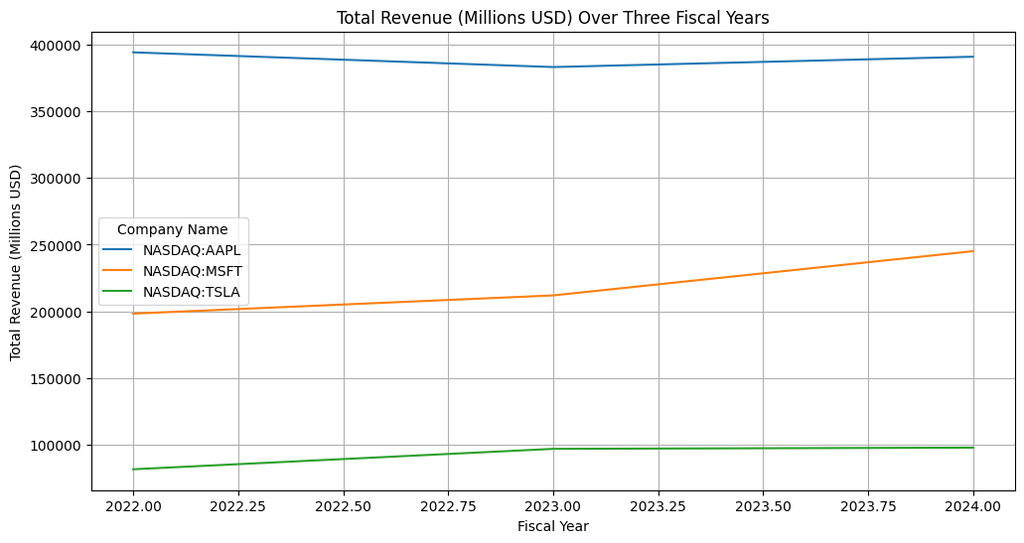

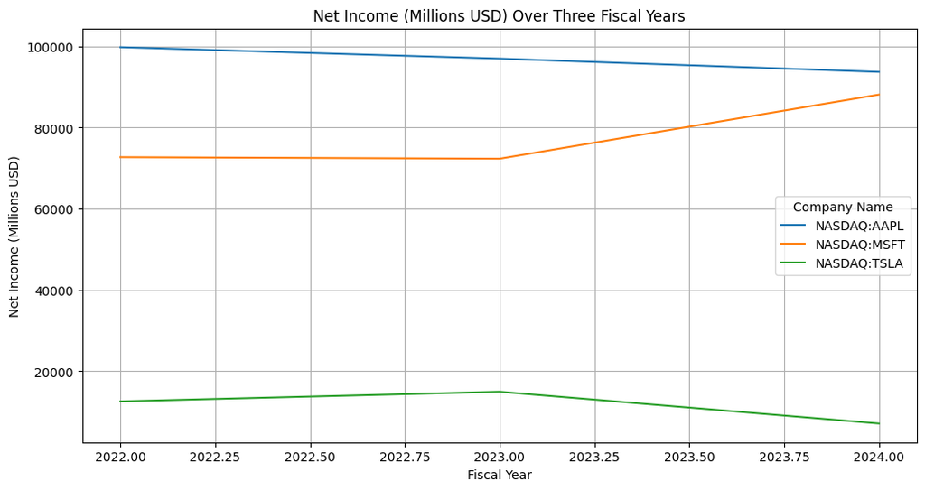

```python
# Data Visualization : Revenue and Net Income Trends Over Time
import matplotlib.pyplot as plt

plot_df = df.pivot_table(
    index='Fiscal Year',
    columns='Company Name',
    values=['Total revenue(Millions USD)', 'Net Income(Millions USD)']
)

plot_df['Total revenue(Millions USD)'].plot(kind='line', figsize=(12, 6))
plt.title('Total Revenue (Millions USD) Over Three Fiscal Years')
plt.xlabel('Fiscal Year')
plt.ylabel('Total Revenue (Millions USD)')
plt.grid(True)
plt.show()

plot_df['Net Income(Millions USD)'].plot(kind='line', figsize=(12, 6))
plt.title('Net Income (Millions USD) Over Three Fiscal Years')
plt.xlabel('Fiscal Year')
plt.ylabel('Net Income (Millions USD)')
plt.grid(True)
plt.show()
```

4. Financial Ratio Analysis: Profitability

To assess each company's profitability and efficiency, a Net Profit Margin ratio was calculated. This metric measures the percentage of revenue that remains after all expenses have been deducted. A pivot table was then generated to provide a clear, side-by-side comparison of how this ratio evolved for each company over the three-year period.

- Observations from the Net Profit Margin analysis:
- Apple: Maintained a very stable and high-level profit margin over the first two years, with a slight dip in 2024. This suggests consistent and strong profitability despite minor revenue fluctuations.
- Microsoft: Shows a consistently high and robust profit margin, indicating strong control over costs relative to its revenue. The margin fluctuated slightly but remained strong across the period.
- Tesla: Experienced a very significant drop in its profit margin in 2024, falling from a relatively stable level in the previous two years. This is a critical observation and reflects the profitability challenges noted earlier in the growth analysis.

```python
# Pivot for Ratio Comparison : Create a pivot table to easily compare how the Net Profit Margin changed for each company over the years.
# Pivot table showing Net Profit Margin (%) by company and year
profit_margin_pivot = df.pivot_table(
    index='Company Name',
    columns='Fiscal Year',
    values='Net Profit Margin (%)'
)
print("\nNet Profit Margin (%) by Company and Year:")
print(profit_margin_pivot)
```

```
Net Profit Margin (%) by Company and Year:
Fiscal Year        2022       2023       2024
Company Name
NASDAQ:AAPL   25.309641  25.306234  23.971256
NASDAQ:MSFT   36.686337  34.146238  35.955973
NASDAQ:TSLA   15.451376  15.473324   7.322141
```

This analysis provides a high-level financial overview. For a deeper understanding, further investigation into specific operational expenses, market conditions, and sector-specific metrics would be required.